# Predicting Movie Gross Revenue

## Introduction

Dataset: IMDb movie data (1986–2016), including budget, cast, ratings, genre, and more  
- Goal: Build models that **predict a movie’s gross revenue**  
- Approach:

- Each group member cleaned specific variables
- Combined into one final dataset
- Applied multiple modeling methods:
  - Linear Regression
  - LASSO
  - Elastic Net
  - Tree Models

**Focus: Which predictors influence revenue the most, and which model performs best?**

## Data Cleaning

**Date**

- Extracted month from “date” column
- Used this to assign each entry a season (Fall, Winter, Spring, Summer)

**Movie Title**

- Sentiment analysis using AFINN
- Added Punctuation

**Budget**

- Almost 1/3 missing or 0
- Flagged and Filled

## Data Cleaning (cont.)

**Director & Company** - Calculated frequency

**Country** - Assigned to regions

**Genre, Rating, Writer & Stars** - Also quantified with frequency in dataset

## Pure Linear Regression

- Used cleaned predictors from compiled csv
- Fit on log(gross) scale for stability
- Predictions were converted back to the dollar scale for interpretation

## Model Performance

**\(R^2\) = 0.594**

**RMSE = $42.3 million**

**MAE = 19043383**

Most Significant Predictors

| Predictor | Percent Impact on Gross | p-value |
| --- | --- | --- |
| ratingG | 4971.20 | 1.38e-02 |
| ratingPG | 2637.40 | 3.72e-02 |
| runtime | 281.60 | 0.00e+00 |
| comp_freq | 135.01 | 0.00e+00 |
| regionSoutheastern Europe | -97.21 | 2.91e-02 |
| regionNorthern Europe | -90.56 | 1.04e-05 |
| director_popularity | 86.35 | 0.00e+00 |
| votes | 83.04 | 0.00e+00 |

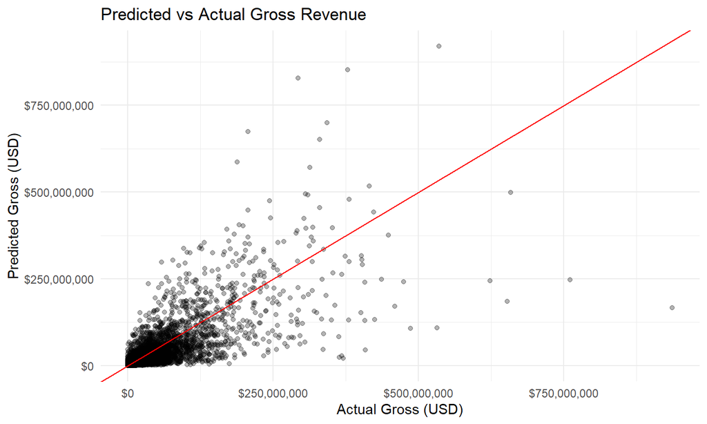

## Elastic Net

- Reminder: Elastic Net is a shrinkage model that combines LASSO and Ridge Regression penalties.
- Why Elastic Net:
  - Large amount of predictors that aren’t meaningful are dropped
  - Handles colinearity well like assuming comp_freq and director popularity
  - Able to rank predictors
  - Stabilize coefficients of correlated predictors

Since our primary goal was to identify strongest predictors, we did not remove possible correlated terms and did not create interaction terms.

## Handling Data:

- How:

** Log transformed gross (response variable)

** Log +1 transformed all numeric predictors

** Dummy encoded the categorical variables: Genre, Region, Rating and Season

10 fold cross-validation

## Hyperparameter Tuning:

Grid of 400 different combos of alpha and lambda

Each combo used to compute metrics for RMSE, MAE, and \(R^2\)

The best RMSE (lowest CV RMSE) was pulled out and revealed the ideal lambda and alpha values.

Finally we are able to pass this back to the workflow and come up with the best elastic net model.

## Cross Validation:

Best Lambda: 0.02636651

Best Alpha: 0.4736842

RMSE: $38.5 million

\(R^2\): 0.584

MAE: $19.3 million

## Prediction Model:

**Prediction:**

RMSE: $37.7 million

R^2 : 0.5909

MAE: $18.4 million

The RMSE from cross-validation (38.5 million) and RMSE from prediction (37.7 million) are very close, indicating the model is stable and not overfitting.

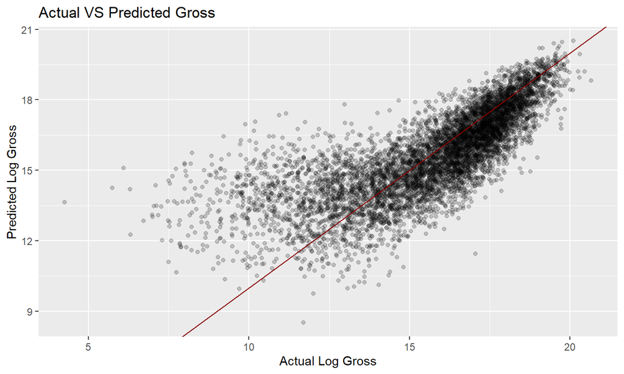

## Predictors:

Total predictors: 53

Leftover: 39 and Shrunk to Zero: 14

**Strongest predictors:** - Votes (0.966)

- comp_freq (0.444)
- rating_Unknown (-0.441)

**Moderate Predictors:**

- Director_popularity (0.225)
- Runtime (0.179)
- Budget (0.113)

## Predictors (cont.)

**Predictors that shrunk to 0:**

- Sentiment
- Oceania
- Genre: Musical

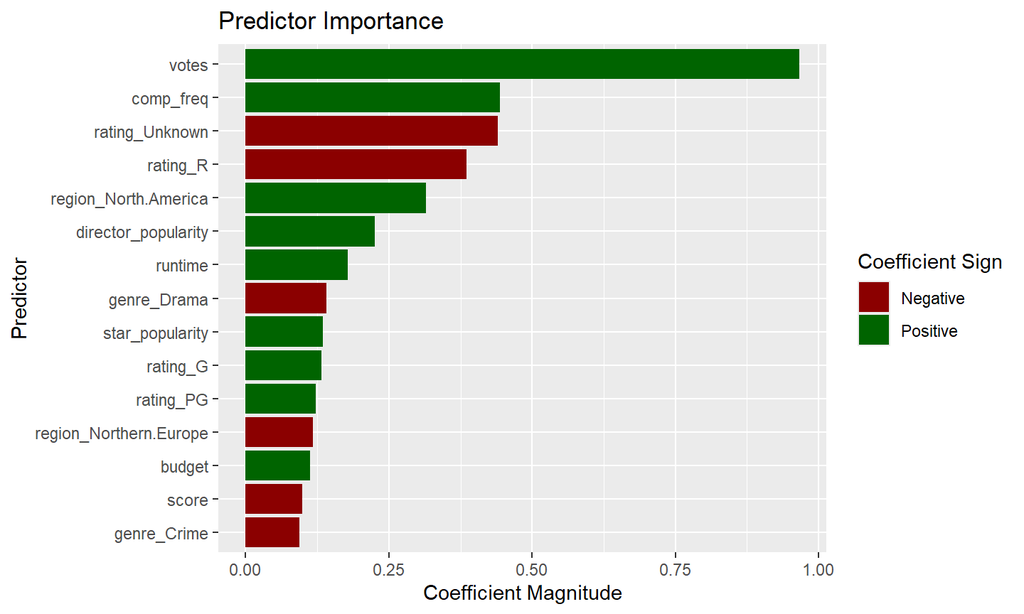

## Elastic Net Takeaway:

- Identified important predictors
- High-gross movies are predicted more accurately than low-gross movies
- Demonstrates stability as it performs very similarly between cross-validation and full-data predictions.

## LASSO Model:

```
##         variable             level coefficient  abs_coef
## 1    (Intercept)              <NA>   542771897 542771897
## 2           star         Tom Hanks    28229752  28229752
## 3           star     Nicole Kidman   -26697096  26697096
## 4           star    Sandra Bullock    22786020  22786020
## 5           star Leonardo DiCaprio    19510870  19510870
## 6 budget_missing              <NA>   -17378927  17378927
```

## Results

```
## LASSO rmse: $ 38555092
```

## Tree Based Models

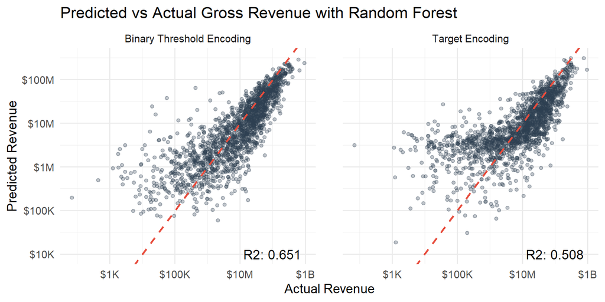

## Random Forest Performance

| Metric | Value |
| --- | --- |
| R-Squared | 0.651 |
| RMSE (Dollars) | $38,897,619 |
| MAE (Dollars) | $16,793,531 |
| MdAPE (Median Avg % Error) | 59% |

- Poor model relative to the median gross revenue ~$14m
- Has some utility predicting high vs low performers

## Overall Results and Conclusion

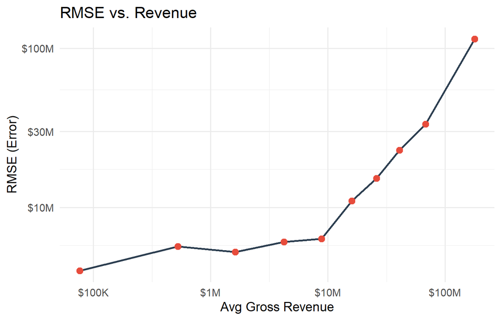

## Data Limitations

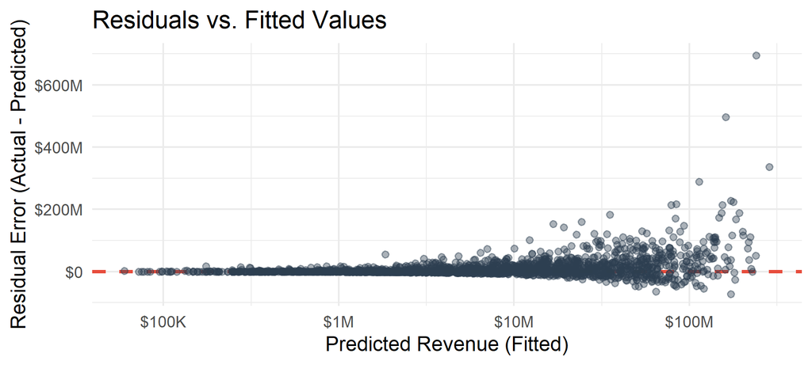